# Lab 3: Friction Forces

**Course:** PHYS 216-503

**Created Date:** 9 March 2022

```python
import pandas as pd
import numpy as np
import matplotlib.pyplot as plt

%load_ext autoreload

pd.options.display.float_format = '{:,.5f}'.format
pd.options.display.max_columns = 100
plt.style.use('seaborn-darkgrid')

# General Markdown Formatting Functions
from IPython.display import Markdown, display, HTML, JSON

def printmd(string: str, level: int=1):
    '''Display Markdown text with a default header value of 1.'''
    header_level = '#'*level + ' '
    display(Markdown(header_level + string))
```

```
The autoreload extension is already loaded. To reload it, use:
  %reload_ext autoreload
```

```python
%autoreload
import friction_experiment

# Initialize each experiment.
static_big = friction_experiment.FrictionExperiment(type='static', surface='big', trials=9)
static_small = friction_experiment.FrictionExperiment(type='static', surface='small', trials=9)
kinetic_big = friction_experiment.FrictionExperiment(type='kinetic', surface='big', trials=9)
kinetic_small = friction_experiment.FrictionExperiment(type='kinetic', surface='small', trials=9)
```

## Theory

Angle of Decline $$\begin{aligned} \bar{r}_{\mathrm{Base}} &= \bar{r}_{\mathrm{Green}} - \bar{r}_{\mathrm{Orange}} \\ \bar{r}_{\mathrm{Ramp}} &= \bar{r}_{\mathrm{Pink}} - \bar{r}_{\mathrm{Orange}}\\ \theta &= \frac{ \bar{r}_{\mathrm{Base}} \cdot \bar{r}_{\mathrm{Ramp}} }{ \| \bar{r}_{\mathrm{Base}} \| \cdot \| \bar{r}_{\mathrm{Ramp}} \| } \end{aligned}$$

Static Friction Coefficient
$$\begin{aligned} \sum \bar{F} &= \bar{F_N} + \bar{F_f} + \bar{F_{g_{\parallel}}} + \bar{F_{g_{\perp}}} = 0 \\ \bar{F_f} &= \bar{F_{g_{\parallel}}} \\ \mu_s \bar{F_N} &= \bar{F_{g_{\parallel}}} \\ \mu_s m g \cos(\theta) &= m g \sin(\theta) \\ \mu_s &= \tan(\theta) \end{aligned}$$

Kinetic Friction Coefficient
$$\begin{aligned} m a &= \bar{F_{g_{\parallel}}} - \bar{F_f}\\ m a &= m g \sin(\theta) - \mu_k m g \cos(\theta)\\ \mu_k &= \frac{1}{\cos(\theta)} \times (\sin(\theta) - \frac{a}{g}) \end{aligned}$$

## Data Analysis

```python
# Show and summarize the contents of one of the trials.
printmd("Static Friction - Small Area: Trial 1 - Raw Data Collected", 3)
print('Units: timestamp (ms), px-(px), r-(m), v-(m/s), a-(m/s^2)')
display(static_small.trials[0].raw_data)
display(static_small.trials[0].raw_data.describe())
```

Static Friction - Small Area: Trial 1 - Raw Data Collected

```
Units: timestamp (ms), px-(px), r-(m), v-(m/s), a-(m/s^2)
```

|  | frame_no | timestamp | size_px-darkorange | position_px_x-darkorange | position_px_y-darkorange | rx-darkorange | ry-darkorange | vx-darkorange | vy-darkorange | ax-darkorange | ay-darkorange | size_px-green | position_px_x-green | position_px_y-green | rx-green | ry-green | vx-green | vy-green | ax-green | ay-green | size_px-hotpink | position_px_x-hotpink | position_px_y-hotpink | rx-hotpink | ry-hotpink | vx-hotpink | vy-hotpink | ax-hotpink | ay-hotpink | … |
| --- | --- | --- | --- | --- | --- | --- | --- | --- | --- | --- | --- | --- | --- | --- | --- | --- | --- | --- | --- | --- | --- | --- | --- | --- | --- | --- | --- | --- | --- | --- |
| 0 | 0 | 135.60000 | NaN | NaN | NaN | NaN | NaN | NaN | NaN | NaN | NaN | NaN | NaN | NaN | NaN | NaN | NaN | NaN | NaN | NaN | NaN | NaN | NaN | NaN | NaN | NaN | NaN | NaN | NaN | … |
| 1 | 1 | 135.60000 | NaN | NaN | NaN | NaN | NaN | NaN | NaN | NaN | NaN | NaN | NaN | NaN | NaN | NaN | NaN | NaN | NaN | NaN | NaN | NaN | NaN | NaN | NaN | NaN | NaN | NaN | NaN | … |
| 2 | 2 | 244.80000 | NaN | NaN | NaN | NaN | NaN | NaN | NaN | NaN | NaN | NaN | NaN | NaN | NaN | NaN | NaN | NaN | NaN | NaN | NaN | NaN | NaN | NaN | NaN | NaN | NaN | NaN | NaN | … |
| 3 | 3 | 266.00000 | 0.15000 | 9.89000 | 0.64000 | 0.65547 | 0.04242 | NaN | NaN | NaN | NaN | 0.14000 | 0.65000 | 0.78000 | 0.04308 | 0.05170 | NaN | NaN | NaN | NaN | NaN | NaN | NaN | NaN | NaN | NaN | NaN | NaN | NaN | … |
| 4 | 4 | 286.60000 | 0.15000 | 9.89000 | 0.65000 | 0.65547 | 0.04308 | NaN | NaN | NaN | NaN | 0.14000 | 0.65000 | 0.78000 | 0.04308 | 0.05170 | NaN | NaN | NaN | NaN | 0.14000 | 0.75000 | 3.39000 | 0.04971 | 0.22468 | NaN | NaN | NaN | NaN | … |
| ... | ... | ... | ... | ... | ... | ... | ... | ... | ... | ... | ... | ... | ... | ... | ... | ... | ... | ... | ... | ... | ... | ... | ... | ... | ... | ... | ... | ... | ... | … |
| 423 | 423 | 14,110.40000 | 0.15000 | 9.90000 | 0.64000 | 0.65613 | 0.04242 | 0.00000 | 0.00000 | 0.00000 | 0.00000 | 0.14000 | 0.66000 | 0.79000 | 0.04374 | 0.05236 | -0.00331 | 0.00000 | -0.06608 | 0.00000 | 0.14000 | 1.58000 | 5.25000 | 0.10472 | 0.34795 | -0.00330 | -0.00661 | 0.06595 | -0.00013 | … |
| 424 | 424 | 14,142.20000 | 0.15000 | 9.90000 | 0.64000 | 0.65613 | 0.04242 | 0.00000 | 0.00000 | 0.00000 | 0.00000 | 0.14000 | 0.65000 | 0.78000 | 0.04308 | 0.05170 | 0.00000 | -0.00005 | 0.00000 | 0.13189 | 0.14000 | 1.59000 | 5.25000 | 0.10538 | 0.34795 | -0.00328 | -0.00328 | -0.06572 | -0.06572 | … |
| 425 | 425 | 14,174.70000 | 0.15000 | 9.90000 | 0.64000 | 0.65613 | 0.04242 | NaN | NaN | NaN | NaN | 0.14000 | 0.65000 | 0.78000 | 0.04308 | 0.05170 | NaN | NaN | NaN | NaN | 0.14000 | 1.59000 | 5.25000 | 0.10538 | 0.34795 | NaN | NaN | NaN | NaN | … |
| 426 | 426 | 14,210.50000 | 0.15000 | 9.90000 | 0.64000 | 0.65613 | 0.04242 | NaN | NaN | NaN | NaN | 0.14000 | 0.65000 | 0.79000 | 0.04308 | 0.05236 | NaN | NaN | NaN | NaN | 0.14000 | 1.58000 | 5.24000 | 0.10472 | 0.34729 | NaN | NaN | NaN | NaN | … |
| 427 | 427 | 14,242.80000 | 0.15000 | 9.90000 | 0.64000 | 0.65613 | 0.04242 | NaN | NaN | NaN | NaN | 0.14000 | 0.65000 | 0.79000 | 0.04308 | 0.05236 | NaN | NaN | NaN | NaN | 0.15000 | 1.58000 | 5.24000 | 0.10472 | 0.34729 | NaN | NaN | NaN | NaN | … |

428 rows × 47 columns

|  | frame_no | timestamp | size_px-darkorange | position_px_x-darkorange | position_px_y-darkorange | rx-darkorange | ry-darkorange | vx-darkorange | vy-darkorange | ax-darkorange | ay-darkorange | size_px-green | position_px_x-green | position_px_y-green | rx-green | ry-green | vx-green | vy-green | ax-green | ay-green | size_px-hotpink | position_px_x-hotpink | position_px_y-hotpink | rx-hotpink | ry-hotpink | vx-hotpink | vy-hotpink | ax-hotpink | ay-hotpink | … |
| --- | --- | --- | --- | --- | --- | --- | --- | --- | --- | --- | --- | --- | --- | --- | --- | --- | --- | --- | --- | --- | --- | --- | --- | --- | --- | --- | --- | --- | --- | --- |
| count | 428.00000 | 428.00000 | 425.00000 | 425.00000 | 425.00000 | 425.00000 | 425.00000 | 419.00000 | 419.00000 | 419.00000 | 419.00000 | 425.00000 | 425.00000 | 425.00000 | 425.00000 | 425.00000 | 419.00000 | 419.00000 | 419.00000 | 419.00000 | 424.00000 | 424.00000 | 424.00000 | 424.00000 | 424.00000 | 418.00000 | 418.00000 | 418.00000 | 418.00000 | … |
| mean | 213.50000 | 7,129.59089 | 0.15012 | 9.89927 | 0.64351 | 0.65608 | 0.04265 | 0.00008 | -0.00017 | -0.00085 | -0.00327 | 0.14000 | 0.65273 | 0.78718 | 0.04326 | 0.05217 | 0.00005 | 0.00001 | -0.00004 | -0.00148 | 0.14901 | 1.11608 | 4.23733 | 0.07397 | 0.28083 | 0.00398 | 0.00857 | -0.00024 | 0.00143 | … |
| std | 123.69721 | 4,119.35752 | 0.00108 | 0.00372 | 0.00478 | 0.00025 | 0.00032 | 0.00184 | 0.00271 | 0.06685 | 0.10011 | 0.00000 | 0.00446 | 0.00451 | 0.00030 | 0.00030 | 0.00226 | 0.00283 | 0.08485 | 0.11249 | 0.00299 | 0.34986 | 0.77276 | 0.02319 | 0.05122 | 0.00547 | 0.01277 | 0.06274 | 0.15490 | … |
| min | 0.00000 | 135.60000 | 0.15000 | 9.88000 | 0.64000 | 0.65481 | 0.04242 | -0.00596 | -0.02774 | -0.43284 | -1.02468 | 0.14000 | 0.65000 | 0.78000 | 0.04308 | 0.05170 | -0.00568 | -0.02774 | -0.59464 | -1.45751 | 0.14000 | 0.74000 | 3.36000 | 0.04904 | 0.22269 | -0.00358 | -0.05548 | -0.19843 | -2.04935 | … |
| 25% | 106.75000 | 3,566.27500 | 0.15000 | 9.90000 | 0.64000 | 0.65613 | 0.04242 | 0.00000 | -0.00001 | 0.00000 | 0.00000 | 0.14000 | 0.65000 | 0.78000 | 0.04308 | 0.05170 | -0.00004 | -0.00003 | -0.06458 | -0.06590 | 0.15000 | 0.79000 | 3.51000 | 0.05236 | 0.23263 | 0.00000 | 0.00000 | -0.06017 | -0.06556 | … |
| 50% | 213.50000 | 7,126.30000 | 0.15000 | 9.90000 | 0.64000 | 0.65613 | 0.04242 | 0.00000 | 0.00000 | 0.00000 | 0.00000 | 0.14000 | 0.65000 | 0.79000 | 0.04308 | 0.05236 | 0.00000 | 0.00000 | 0.00000 | 0.00000 | 0.15000 | 0.97000 | 3.99500 | 0.06429 | 0.26477 | 0.00009 | 0.00332 | 0.00000 | 0.00000 | … |
| 75% | 320.25000 | 10,689.85000 | 0.15000 | 9.90000 | 0.65000 | 0.65613 | 0.04308 | 0.00000 | 0.00000 | 0.00000 | 0.00000 | 0.14000 | 0.66000 | 0.79000 | 0.04374 | 0.05236 | 0.00007 | 0.00006 | 0.06616 | 0.05521 | 0.15000 | 1.52250 | 5.14250 | 0.10091 | 0.34082 | 0.00988 | 0.01944 | 0.00564 | 0.06581 | … |
| max | 427.00000 | 14,242.80000 | 0.16000 | 9.91000 | 0.65000 | 0.65680 | 0.04308 | 0.01391 | 0.01134 | 0.53409 | 0.61988 | 0.14000 | 0.66000 | 0.79000 | 0.04374 | 0.05236 | 0.01180 | 0.01180 | 0.53409 | 0.61988 | 0.15000 | 1.63000 | 5.32000 | 0.10803 | 0.35259 | 0.01720 | 0.04470 | 0.19893 | 1.23975 | … |

## Plots of Static Friction Data

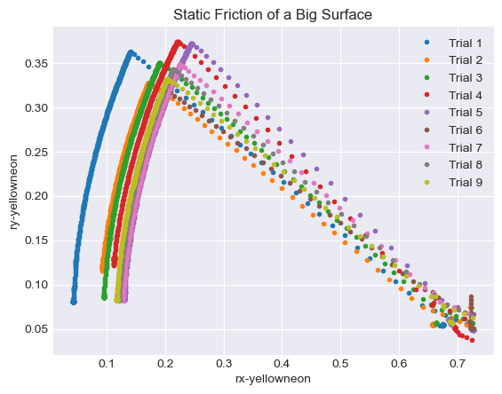

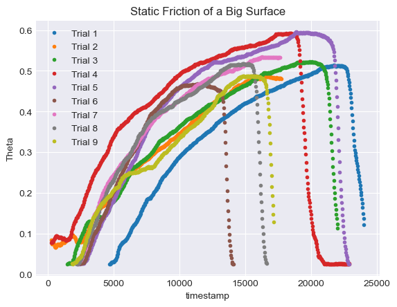

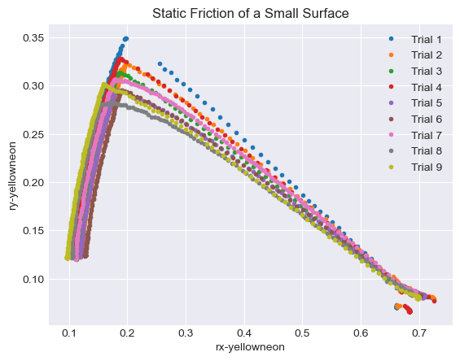

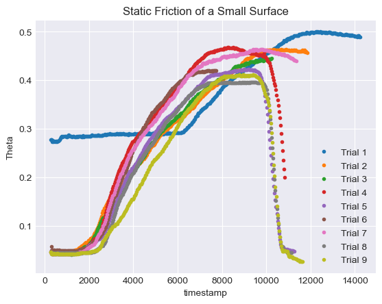

```python
# Display a plot comparing the position of the block over time for each trial.
# Then, display a plot comparing the angle of the ramp over time for each trial.
static_big.plot_raw_data(legend=True)
static_big.plot_calculations(legend=True)

static_small.plot_raw_data(legend=True)
static_small.plot_calculations(legend=True)
```

## Plots of Kinetic Friciton Data

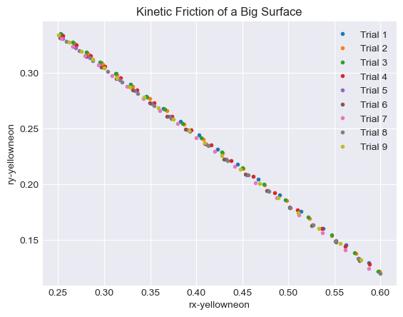

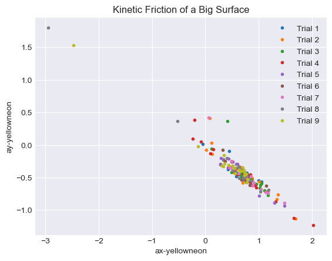

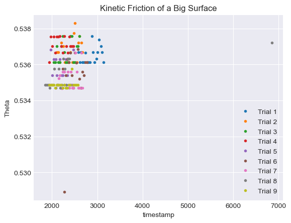

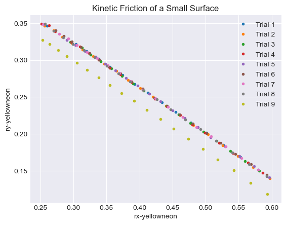

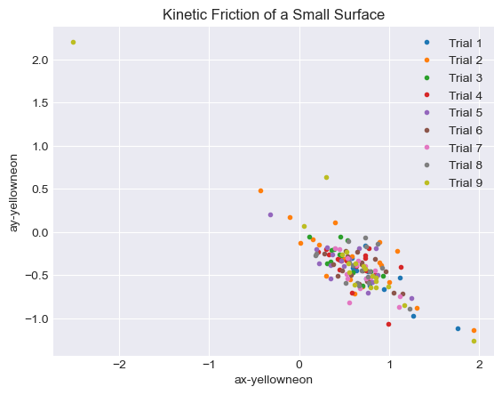

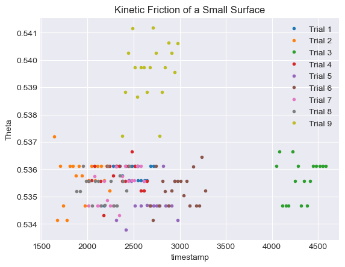

```python
# Display a plot comparing the position of the block over time for each trial.
# Then, display a plot comparing the acceleration of the block over time for each trial.
# Finally, display a plot comparing the angle of the ramp over time for each trial.
kinetic_big.plot_raw_data(legend=True)
kinetic_big.plot_raw_data(x='ax-yellowneon', y='ay-yellowneon', legend=True)
kinetic_big.plot_calculations(legend=True)

kinetic_small.plot_raw_data(legend=True)
kinetic_small.plot_raw_data(x='ax-yellowneon', y='ay-yellowneon', legend=True)
kinetic_small.plot_calculations(legend=True)
```

## Results

```python
# Tabulate the calculated friction coefficient of each trial in each experiment.
# Tabulate the mean and confidence interval of the friction coefficient in each experiment.
static_results = pd.DataFrame({
    'Large Area': static_big.mu,
    'Small Area': static_small.mu,
    'Trial': range(1, 10)
    }).set_index('Trial')

static_avg = pd.DataFrame({
    'Large Area':
        [f"{static_big.mu_avg:.5f} ± {static_big.mu_error:.5f}",
        f"{static_big.mu_confidence_interval(.95)[0]:.5f} ≥ µ ≥ {static_big.mu_confidence_interval(.95)[1]:.5f}"],
    'Small Area':
        [f"{static_small.mu_avg:.5f} ± {static_small.mu_error:.5f}",
        f"{static_small.mu_confidence_interval(.95)[0]:.5f} ≥ µ ≥ {static_small.mu_confidence_interval(.95)[1]:.5f}"]},
    index=['Average', '95% Conf']
    ).style.set_properties(**{'text-align': 'center'}
    ).set_table_styles([dict(selector='th', props=[('text-align', 'center')])])

kinetic_results = pd.DataFrame({
    'Large Area': kinetic_big.mu,
    'Small Area': kinetic_small.mu,
    'Trial': range(1, 10)
    }).set_index('Trial')

kinetic_avg = pd.DataFrame({
    'Large Area':
        [f"{kinetic_big.mu_avg:.5f} ± {kinetic_big.mu_error:.5f}",
        f"{kinetic_big.mu_confidence_interval(.95)[0]:.5f} ≥ µ ≥ {kinetic_big.mu_confidence_interval(.95)[1]:.5f}"],
    'Small Area':
        [f"{kinetic_small.mu_avg:.5f} ± {kinetic_small.mu_error:.5f}",
        f"{kinetic_small.mu_confidence_interval(.95)[0]:.5f} ≥ µ ≥ {kinetic_small.mu_confidence_interval(.95)[1]:.5f}"]},
    index=['Average', '95% Conf']
    ).style.set_properties(**{'text-align': 'center'}
    ).set_table_styles([dict(selector='th', props=[('text-align', 'center')])])

printmd("Coefficient of Static Friction", 3)
display(static_results)
display(static_avg)

printmd("Coefficient of Kinetic Friction", 3)
display(kinetic_results)
display(kinetic_avg)
```

Coefficient of Static Friction

| Trial | Large Area | Small Area |
| --- | --- | --- |
| 1 | 0.55766 | 0.52844 |
| 2 | 0.51608 | 0.47587 |
| 3 | 0.56481 | 0.44508 |
| 4 | 0.65720 | 0.47697 |
| 5 | 0.66065 | 0.39673 |
| 6 | 0.49341 | 0.40580 |
| 7 | 0.58206 | 0.42013 |
| 8 | 0.55822 | 0.36181 |
| 9 | 0.52384 | 0.39870 |

|  | Large Area | Small Area |
| --- | --- | --- |
| Average | 0.56821 ± 0.01831 | 0.43439 ± 0.01628 |
| 95% Conf | 0.53232 ≥ µ ≥ 0.60410 | 0.40248 ≥ µ ≥ 0.46631 |

Coefficient of Kinetic Friction

| Trial | Large Area | Small Area |
| --- | --- | --- |
| 1 | 0.50014 | 0.46888 |
| 2 | 0.48944 | 0.49840 |
| 3 | 0.48735 | 0.52242 |
| 4 | 0.48492 | 0.50499 |
| 5 | 0.50084 | 0.51120 |
| 6 | 0.49464 | 0.49788 |
| 7 | 0.48225 | 0.49195 |
| 8 | 0.47826 | 0.49689 |
| 9 | 0.50031 | 0.47444 |

|  | Large Area | Small Area |
| --- | --- | --- |
| Average | 0.49091 ± 0.00266 | 0.49634 ± 0.00525 |
| 95% Conf | 0.48570 ≥ µ ≥ 0.49611 | 0.48604 ≥ µ ≥ 0.50664 |

## Observations

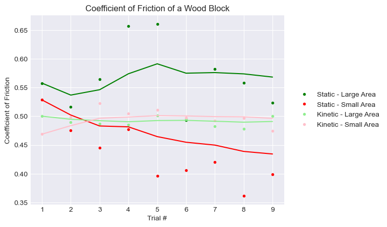

```python
# Plot the calculated coefficients and analyze any trends.
static_results['Large Area Rolling Mean'] = static_results['Large Area'].expanding(1).mean()
static_results['Small Area Rolling Mean'] = static_results['Small Area'].expanding(1).mean()
plt.plot('Large Area', '.', data = static_results, c='green', label='Static - Large Area')
plt.plot('Small Area', '.', data = static_results, c='red', label='Static - Small Area')

kinetic_results['Large Area Rolling Mean'] = kinetic_results['Large Area'].expanding(1).mean()
kinetic_results['Small Area Rolling Mean'] = kinetic_results['Small Area'].expanding(1).mean()
plt.plot('Large Area', '.', data = kinetic_results, c='lightgreen', label='Kinetic - Large Area')
plt.plot('Small Area', '.', data = kinetic_results, c='pink', label='Kinetic - Small Area')

plt.legend(bbox_to_anchor=(1.04,0.5), loc="center left", borderaxespad=0)

plt.plot('Large Area Rolling Mean', data = static_results, c='green',)
plt.plot('Small Area Rolling Mean', data = static_results, c='red')

plt.plot('Large Area Rolling Mean', data = kinetic_results, c='lightgreen', label=None)
plt.plot('Small Area Rolling Mean', data = kinetic_results, c='pink')

plt.title('Coefficient of Friction of a Wood Block')
plt.xlabel('Trial #')
plt.ylabel('Coefficient of Friction')
plt.show()
```

The *Kinetic - Large Area* and *Kinetic - Small Area* values has a strong correlation, supporing the hypothesis that $\mu$ is not dependent on surface area, and it is only dependent on surface material and mass. These calculated values of $\mu_k$ trends towards a converging value.

The calculated values of $\mu_s$ in the *Static - Large Area* exeperiment indicates that $\mu_s$ is greater than $\mu_k$. The calculated values of $\mu_s$ in the *Static - Small Area* exeperiment, however, do not support this. Observing the plot above, these values of $\mu_s$ (red) are shown to get lower for each subsequent trial. As this trend line has a steady negative slope, it can be speculated that if more trials were taken in this way, the data would become even less accurate, before it improve.

This was likely caused a flaw in the experiment's execution, potentially due to human error.